# multi-Chemokine Receptor Analysis

Kilicali Isildayancan

2023-04-17

# A0A6B0S3N8

## First Domain

Sequence [66-360]: VGQIEAQLLPPLYSLVFIFGFVGNLLVVLILINCKKLKSMTDIYLLNLAISDLLFLLTMP…

### Homologies

Psi-blast search against Swiss-Prot:

#### First 5 Full Homologues

```
##                   Receptor Name          Organism Percent Identity Query Cover
## 1 C-C chemokine receptor type 2    Macaca mulatta            84.07        100%
## 2 C-C chemokine receptor type 2 Rattus norvegicus            82.03        100%
## 3 C-C chemokine receptor type 2      Mus musculus            81.69        100%
## 4 C-C chemokine receptor type 5        Bos taurus            83.56         99%
## 5 C-C chemokine receptor type 2      Homo sapiens            84.48         93%
##   E value
## 1     0.0
## 2     0.0
## 3  2e-179
## 4  2e-179
## 5  1e-174
```

#### First 50 Unique Homologues

```
##                    Receptor Name Percent Identity
## 1  C-C chemokine receptor type 2            84.07
## 2  C-C chemokine receptor type 2            82.03
## 3  C-C chemokine receptor type 2            81.69
## 4  C-C chemokine receptor type 5            83.56
## 5  C-C chemokine receptor type 2            84.48
## 6  C-C chemokine receptor type 5            80.20
## 7  C-C chemokine receptor type 5            80.20
## 8  C-C chemokine receptor type 5            79.19
## 9  C-C chemokine receptor type 5            77.59
## 10 C-C chemokine receptor type 5            79.93
## 11 C-C chemokine receptor type 5            81.21
## 12 C-C chemokine receptor type 5            80.87
## 13 C-C chemokine receptor type 5            80.54
## 14 C-C chemokine receptor type 5            80.87
```

[output cut: 36 more lines]

The similarity of the 50th match: 61% identity.

### Motifs

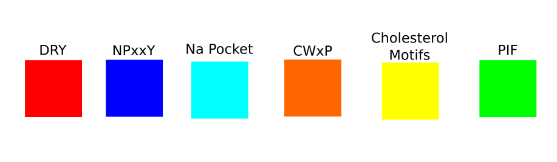

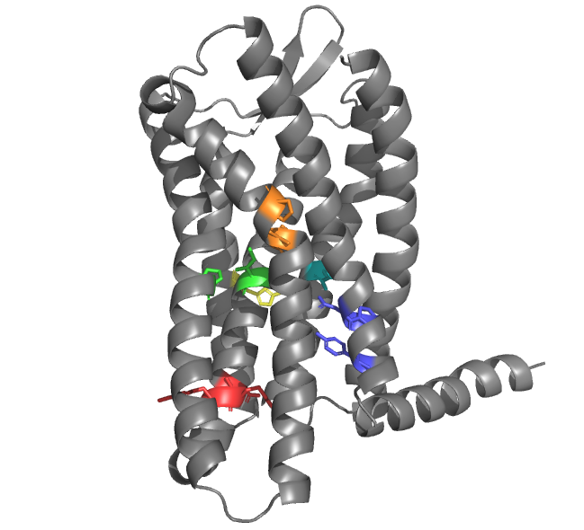

### Conservation

Conservation of the protein from SwissProt with highest homology to the first domain: C-C chemokine receptor type 2, UniProt ID: O18793

#### Conservation in the homolog

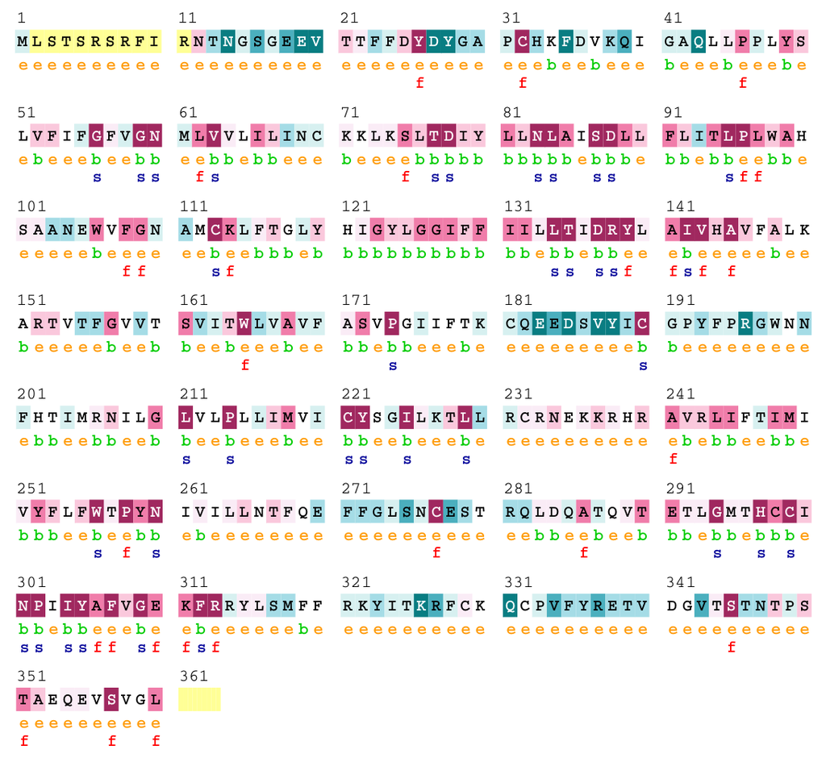

#### Pairwise alignment with homolog

Looking at the conserved sites predicted by ConSurf, and cross-referencing to our first domain sequence:

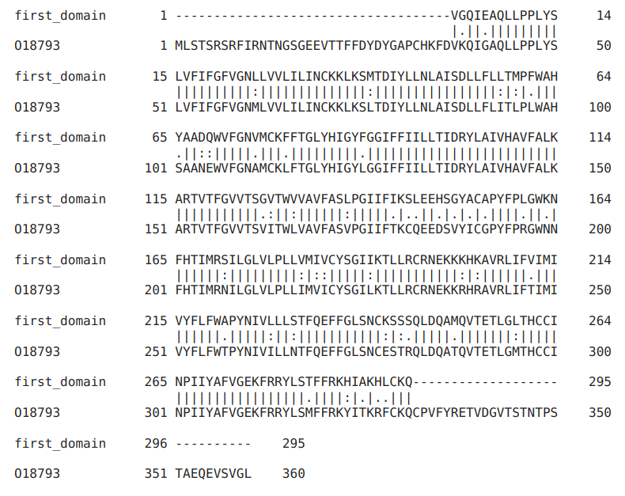

#### Binding ligands of homolog

7XA3 is with natural ligand (CCL2), 6GPX is a non-natural ligand (MK-0812),

#### Ligand superimposition of domain and homolog with ligand

RMSD with the ligand-bound receptor: 1.391

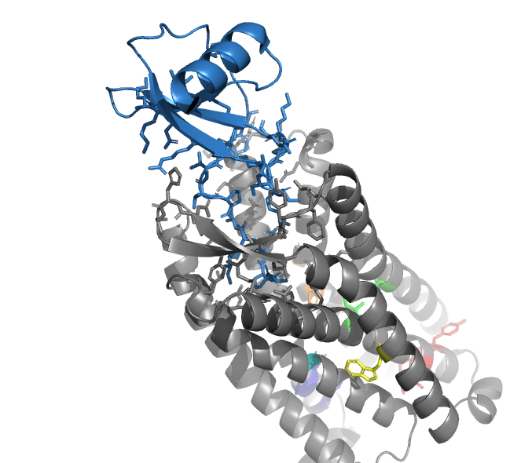

#### Structural sequence alignment between binding pockets

RMSD: 1.848

#### Superimposition with Consurf’d best homologue

RMSD: 0.556

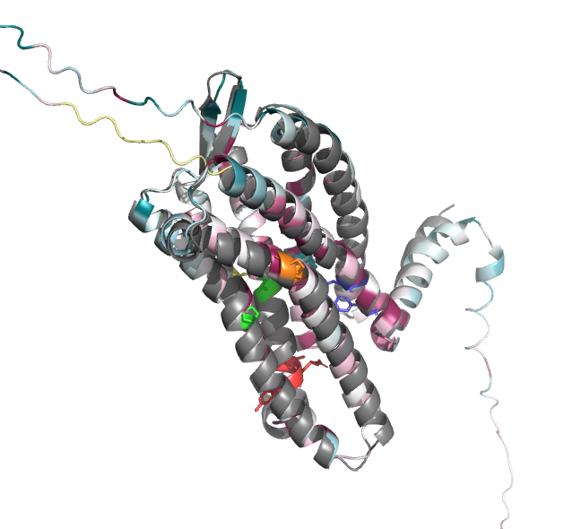

* Both are AlphaFold predicted structures

## Second domain

Sequence [412-709]: LNVRQIAARLLPPLYSLVFIFGFVGNMLVVLILINCKKLKSMTDIYLLNLAISDLLFIIT…

### Homologies

Psi-blast search against Swiss-Prot:

#### First 5 Full Homologues

```
##                   Receptor Name              Organism Percent Identity
## 1 C-C chemokine receptor type 5            Bos taurus            99.66
## 2 C-C chemokine receptor type 5 Allochrocebus lhoesti            87.58
## 3 C-C chemokine receptor type 5 Allochrocebus solatus            87.58
## 4 C-C chemokine receptor type 5       Cercocebus atys            87.58
## 5 C-C chemokine receptor type 5        Pongo pygmaeus            87.25
##   Query Cover E value
## 1        100%     0.0
## 2        100%     0.0
## 3        100%     0.0
## 4        100%     0.0
## 5        100%     0.0
```

#### First 50 Unique Homologues

```
##                    Receptor Name Percent Identity
## 1  C-C chemokine receptor type 5            99.66
## 2  C-C chemokine receptor type 5            87.58
## 3  C-C chemokine receptor type 5            87.58
## 4  C-C chemokine receptor type 5            87.58
## 5  C-C chemokine receptor type 5            87.25
## 6  C-C chemokine receptor type 5            87.25
## 7  C-C chemokine receptor type 5            87.25
## 8  C-C chemokine receptor type 5            86.91
## 9  C-C chemokine receptor type 5            87.25
## 10 C-C chemokine receptor type 5            87.54
## 11 C-C chemokine receptor type 5            86.91
## 12 C-C chemokine receptor type 5            83.56
## 13 C-C chemokine receptor type 5            86.91
## 14 C-C chemokine receptor type 5            86.91
```

[output cut: 36 more lines]

The similarity of the 50th match: 61% identity.

### Motifs

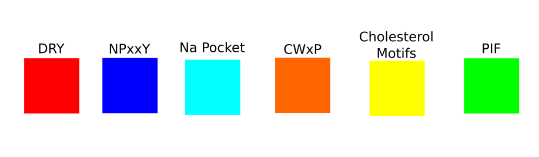

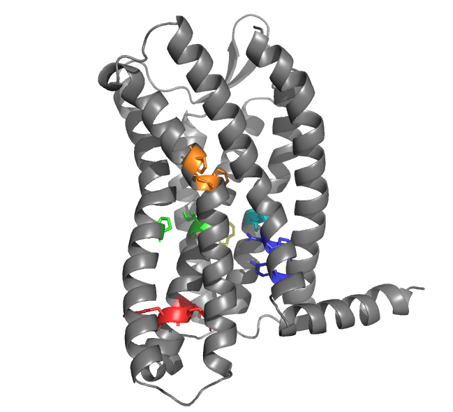

### Conservation

Conservation of the protein from SwissProt with highest homology to the second domain: C-C chemokine receptor type 5, UniProt ID: Q2HJ17

#### Conservation with homolog

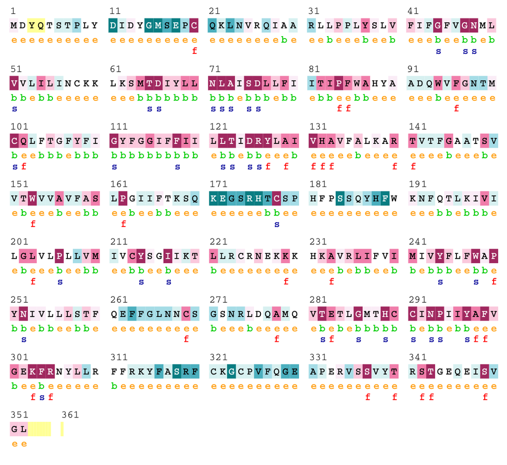

#### Pairwise alignment with homolog

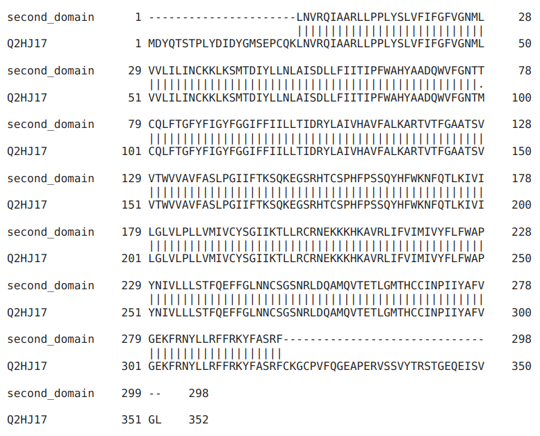

#### Ligand superimposition of domain and homolog with ligand

RMSD with the ligand-bound receptor: 0.506

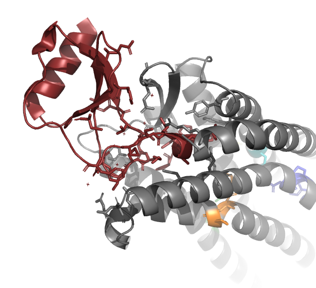

### Structural sequence alignment between binding pockets

This alignment is between the native ligand receptor, and the second domain of the AF predicted structure of our multi-domain GPCR.

RMSD: 0.610

#### Superimposition with Consurf’d best homologue

RMSD: 0.317

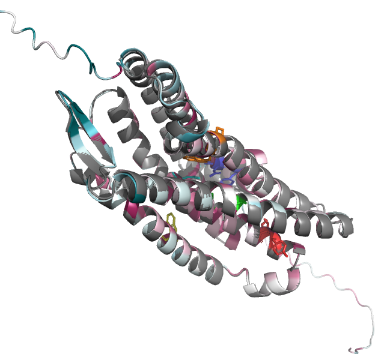

## Relative domains

### Pairwise alignment

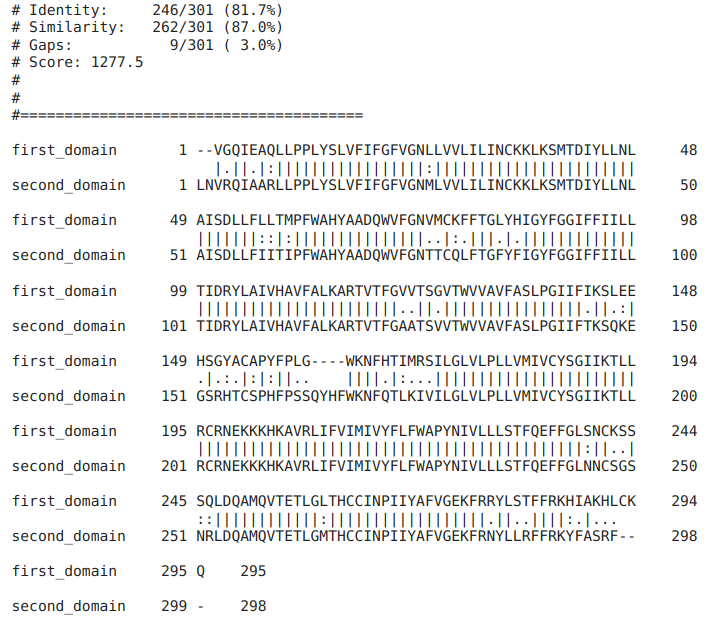

## Genomic sequence

Does not exist in a genome database viewer.